# COM747 Week 2 Seminar: Complete Solutions

Exercises 1–4: apply, factors, missing data, data frames, ggplot2, rundata and probability distributions

> **How to use this notebook.** Every snippet from the four Week 2 exercise sheets, run and explained. Several lines in the sheets don’t work as written or give a misleading answer; each is flagged in an orange box with the fix. Put `rundata.csv` in the same folder as this file.

```r
library(ggplot2)
```

# Exercise 1: apply, factors, table, tapply and missing values

## 1. `apply()`

`apply(m, dimcode, f, fargs)`: run function `f` over the rows (`dimcode = 1`) or columns (`dimcode = 2`) of matrix `m`, passing any extra arguments `fargs` to `f`.

```r
x <- matrix(1:20, nrow = 10, ncol = 2)   # column 1 is 1..10, column 2 is 11..20
x
```

```
##       [,1] [,2]
##  [1,]    1   11
##  [2,]    2   12
##  [3,]    3   13
##  [4,]    4   14
##  [5,]    5   15
##  [6,]    6   16
##  [7,]    7   17
##  [8,]    8   18
##  [9,]    9   19
## [10,]   10   20
```

```r
apply(x, 2, mean)                        # column means: 5.5 15.5
```

```
## [1]  5.5 15.5
```

```r
rowSums  <- apply(x, 1, sum)             # each row: 1+11 = 12, 2+12 = 14, ...
rowMeans <- apply(x, 1, mean)            # 6, 7, ..., 15
colSums  <- apply(x, 2, sum)             # 55 155
colMeans <- apply(x, 2, mean)            # 5.5 15.5
rowSums; rowMeans; colSums; colMeans
```

```
##  [1] 12 14 16 18 20 22 24 26 28 30
```

```
##  [1]  6  7  8  9 10 11 12 13 14 15
```

```
## [1]  55 155
```

```
## [1]  5.5 15.5
```

**Naming trap.** These lines create variables called `rowSums`, `colMeans` etc., the same names as R’s built-in fast functions `rowSums()` and `colMeans()`. It still works (R looks for a *function* when you call one), but it’s confusing. Prefer names like `row_totals`. The built-ins give the same answers faster:

```r
rm(rowSums, rowMeans, colSums, colMeans)       # tidy up the confusing names
base::rowSums(x); base::colMeans(x)
```

```
##  [1] 12 14 16 18 20 22 24 26 28 30
```

```
## [1]  5.5 15.5
```

```r
apply(x, 1, quantile, probs = c(0.25, 0.75))   # probs is passed on to quantile(), not used by apply()
```

```
##     [,1] [,2] [,3] [,4] [,5] [,6] [,7] [,8] [,9] [,10]
## 25%  3.5  4.5  5.5  6.5  7.5  8.5  9.5 10.5 11.5  12.5
## 75%  8.5  9.5 10.5 11.5 12.5 13.5 14.5 15.5 16.5  17.5
```

Each column of the result is one row of `x`; the two rows are the 25th and 75th percentiles.

## 2. Factors

```r
x <- factor(c("yes", "yes", "no", "yes", "no"))
x                     # Levels: no yes (alphabetical by default)
```

```
## [1] yes yes no  yes no
## Levels: no yes
```

```r
levels(x)
```

```
## [1] "no"  "yes"
```

```r
as.integer(x)         # stored as integers 1 = "no", 2 = "yes"
```

```
## [1] 2 2 1 2 1
```

```r
factor(c("low", "high", "medium"), levels = c("low", "medium", "high"), ordered = TRUE)   # ordinal data
```

```
## [1] low    high   medium
## Levels: low < medium < high
```

## 3. `table()`

```r
table(x)              # no 2, yes 3
```

```
## x
##  no yes
##   2   3
```

```r
prop.table(table(x))  # proportions: 0.4 0.6
```

```
## x
##  no yes
## 0.4 0.6
```

## 4. `tapply()`

```r
ages   <- c(25, 26, 37, 56, 42, 25)
affill <- factor(c("U", "R", "R", "D", "D", "U"))
tapply(ages, affill, mean)     # D 49.0, R 31.5, U 25.0
```

```
##    D    R    U
## 49.0 31.5 25.0
```

```r
tapply(ages, affill, range)    # min and max per group
```

```
## $D
## [1] 42 56
##
## $R
## [1] 26 37
##
## $U
## [1] 25 25
```

The sheet’s `factor(c(“U”, “R”, “R”,”D”, “D”, “U”))` has curly quotes, which R rejects (*unexpected input*). Retype them as straight quotes.

## 5. Missing values: NA and NaN

```r
x <- c(25, 26, NA, 56, 42, 25)
is.na(x); is.nan(x)
```

```
## [1] FALSE FALSE  TRUE FALSE FALSE FALSE
```

```
## [1] FALSE FALSE FALSE FALSE FALSE FALSE
```

```r
x <- c(1, 2, NA, 10, 3)
is.na(x)                       # FALSE FALSE TRUE FALSE FALSE
```

```
## [1] FALSE FALSE  TRUE FALSE FALSE
```

```r
is.nan(x)                      # all FALSE
```

```
## [1] FALSE FALSE FALSE FALSE FALSE
```

```r
x <- c(1, 2, NaN, NA, 4)
is.na(x)                       # NaN counts as NA too: FALSE FALSE TRUE TRUE FALSE
```

```
## [1] FALSE FALSE  TRUE  TRUE FALSE
```

```r
is.nan(x)                      # only the NaN: FALSE FALSE TRUE FALSE FALSE
```

```
## [1] FALSE FALSE  TRUE FALSE FALSE
```

```r
0 / 0; sqrt(-1)                # where NaN ("not a number") comes from
```

```
## [1] NaN
```

```
## [1] NaN
```

## 6. Cleansing missing values

```r
x <- c(1, 2, NA, 10, 3)
x[is.na(x)] <- 0               # approach 1: replace with 0
x
```

```
## [1]  1  2  0 10  3
```

```r
x <- c(1, 2, NA, 10, 3)
x[is.na(x)] <- mean(x)         # approach 2 as written in the sheet
x                              # the NA is still NA!
```

```
## [1]  1  2 NA 10  3
```

**Bug in the sheet.** `mean(x)` is `NA` while `x` contains an `NA` (see part 7), so this replaces `NA` with `NA`. Add `na.rm = TRUE`:

```r
x <- c(1, 2, NA, 10, 3)
x[is.na(x)] <- mean(x, na.rm = TRUE)   # mean of 1, 2, 10, 3 = 4
x
```

```
## [1]  1  2  4 10  3
```

**Discuss:** Is replacing with 0 or the mean a good idea? Zero is usually wrong (it’s a real value). Mean imputation keeps the mean but shrinks the spread. Better options: the median for skewed data, imputation from other variables, or leaving NA and saying how many were missing.

## 7. `mean()` with missing values

```r
x <- c(1, 2, NA, 10, 3)
mean(x)                  # NA: R won't guess what the missing value is
```

```
## [1] NA
```

```r
mean(x, na.rm = TRUE)    # 4
```

```
## [1] 4
```

```r
sum(is.na(x))            # always report how many you removed
```

```
## [1] 1
```

# Exercise 2: data frames and ggplot2

## 1. Creating and exploring a data frame

```r
x <- data.frame(names = c("ben", "joe", "steve"), ages = c(31, 24, 45))
nrow(x); ncol(x)         # 3 rows, 2 columns
```

```
## [1] 3
```

```
## [1] 2
```

```r
str(x)                   # structure: column names, types, first values
```

```
## 'data.frame':    3 obs. of  2 variables:
##  $ names: chr  "ben" "joe" "steve"
##  $ ages : num  31 24 45
```

```r
x$names                  # one column by name
```

```
## [1] "ben"   "joe"   "steve"
```

```r
x[x$ages > 30, ]         # rows where age > 30
```

```
##   names ages
## 1   ben   31
## 3 steve   45
```

```r
# data()                 # lists the built-in datasets
x <- mtcars              # ?mtcars: 32 cars from 1974 Motor Trend magazine
head(x)
```

```
##                    mpg cyl disp  hp drat    wt  qsec vs am gear carb
## Mazda RX4         21.0   6  160 110 3.90 2.620 16.46  0  1    4    4
## Mazda RX4 Wag     21.0   6  160 110 3.90 2.875 17.02  0  1    4    4
## Datsun 710        22.8   4  108  93 3.85 2.320 18.61  1  1    4    1
## Hornet 4 Drive    21.4   6  258 110 3.08 3.215 19.44  1  0    3    1
## Hornet Sportabout 18.7   8  360 175 3.15 3.440 17.02  0  0    3    2
## Valiant           18.1   6  225 105 2.76 3.460 20.22  1  0    3    1
```

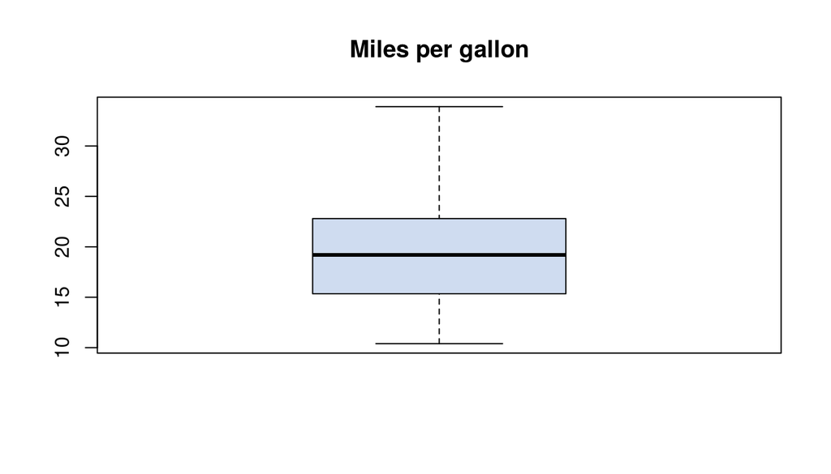

```r
boxplot(mtcars$mpg, main = "Miles per gallon", col = "#cfdcf0")
```

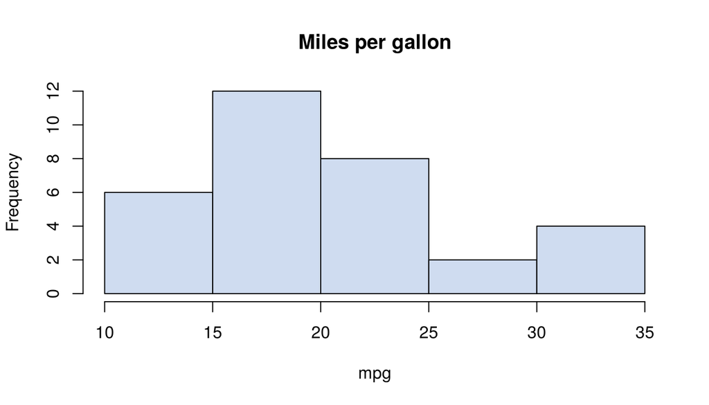

```r
hist(mtcars$mpg, main = "Miles per gallon", xlab = "mpg", col = "#cfdcf0")
```

## 2. Manual vs automatic

In `mtcars`, `am` is the transmission: **0 = automatic, 1 = manual** (see `?mtcars`).

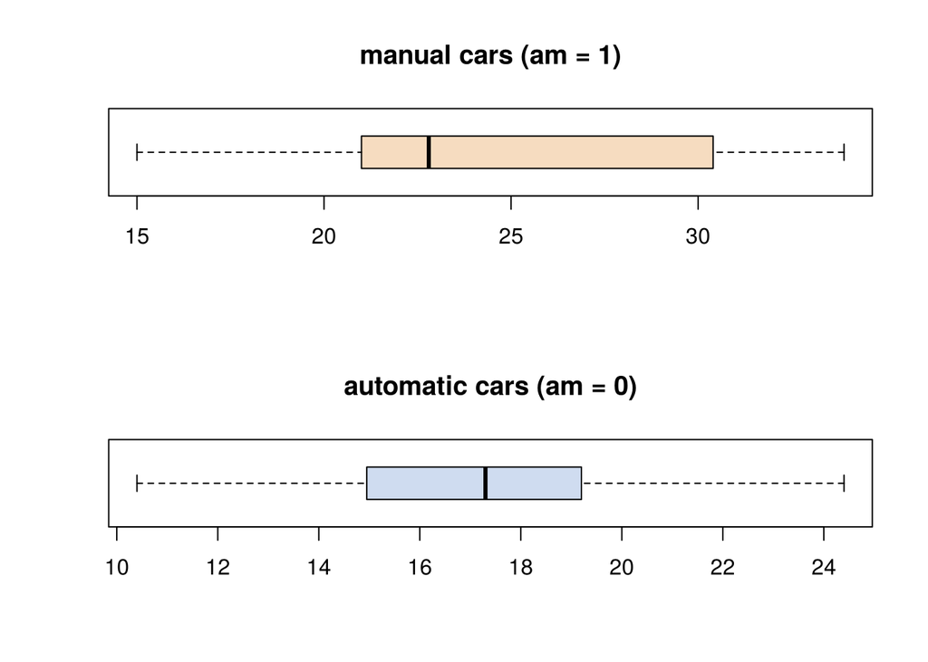

```r
par(mfrow = c(2, 1))
boxplot(mtcars$mpg[mtcars$am == 1], main = "manual cars (am = 1)", horizontal = TRUE, col = "#f6dcc0")
boxplot(mtcars$mpg[mtcars$am == 0], main = "automatic cars (am = 0)", horizontal = TRUE, col = "#cfdcf0")
```

```r
par(mfrow = c(1, 1))
```

**Labels swapped in the sheet.** It labels `am == 1` “auto cars” and `am == 0` “manual cars”. It’s the other way round: 1 = manual. (Also, two separate boxplots get different axes, so they’re hard to compare; the formula version below uses one axis.)

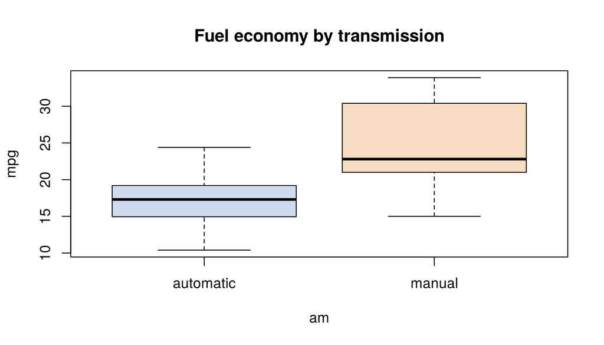

```r
boxplot(mpg ~ am, data = mtcars, names = c("automatic", "manual"), col = c("#cfdcf0", "#f6dcc0"),
        ylab = "mpg", main = "Fuel economy by transmission")
```

```r
tapply(mtcars$mpg, mtcars$am, mean)        # automatic 17.1, manual 24.4
```

```
##        0        1
## 17.14737 24.39231
```

## 3. ggplot2

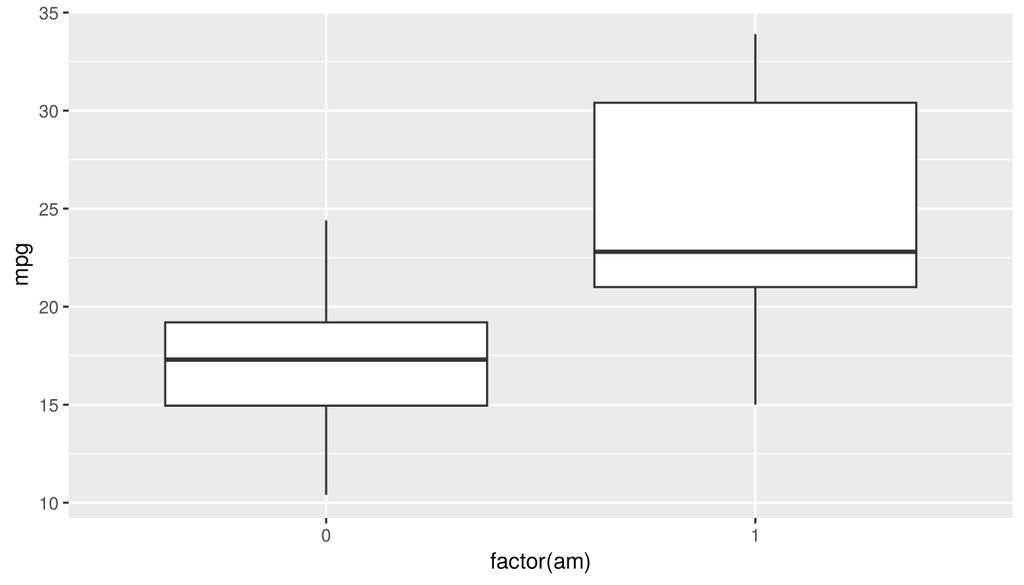

```r
p <- ggplot(mtcars, aes(factor(am), mpg))  # factor(): treat 0/1 as categories, not numbers
p + geom_boxplot()
```

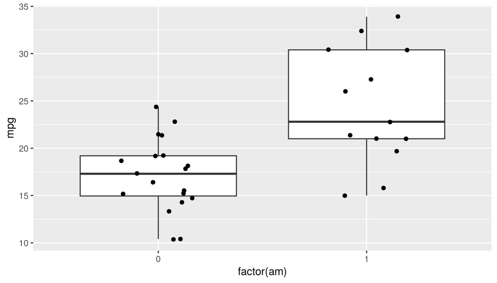

```r
p + geom_boxplot() + geom_jitter(width = 0.2)   # jitter shows every car, spread sideways so they don't overlap
```

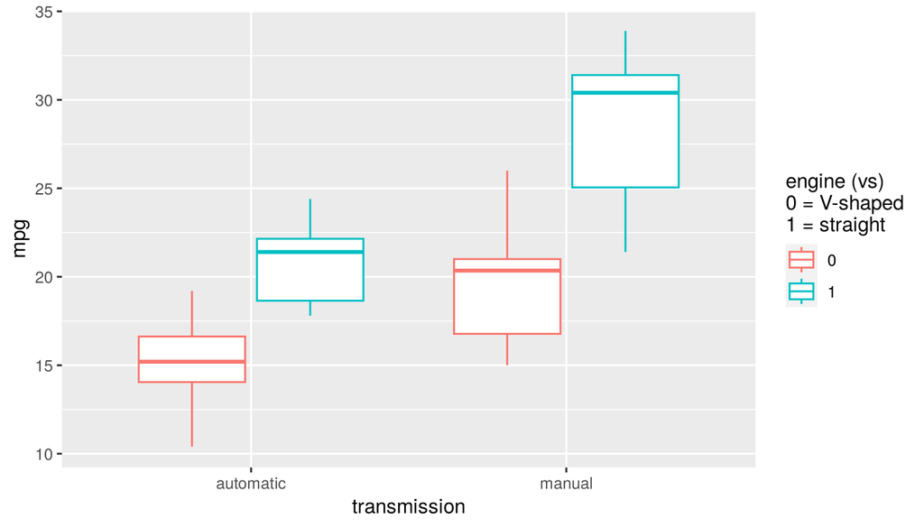

```r
p + geom_boxplot(aes(colour = factor(vs))) +
  scale_x_discrete(labels = c("automatic", "manual")) +
  labs(x = "transmission", colour = "engine (vs)\n0 = V-shaped\n1 = straight")
```

The sheet calls `vs` “engine size”. In `mtcars`, `vs` is the engine **shape**: 0 = V-shaped, 1 = straight. Engine size is `disp` (displacement in cubic inches).

# Exercise 3: the rundata tutorial

```r
rundata <- read.csv("rundata.csv")   # or read.csv(file.choose()) to pick the file
# View(rundata)                      # opens the data viewer in RStudio
str(rundata)                         # 99 runners, three runs (km)
```

```
## 'data.frame':    99 obs. of  3 variables:
##  $ FirstRun : num  7.47 24.16 35.06 30.71 31.03 ...
##  $ SecondRun: num  11.2 29.2 41.8 34 37.6 ...
##  $ FinalRun : num  23.4 38.9 47.9 40.4 41 ...
```

```r
rundata$FirstRun[1:10]
```

```
##  [1]  7.47 24.16 35.06 30.71 31.03 25.74 35.85 22.38 34.30 34.24
```

```r
mean(rundata$FirstRun)
```

```
## [1] 28.7396
```

```r
sd(rundata$FirstRun)
```

```
## [1] 9.53072
```

```r
summary(rundata$FirstRun)
```

```
##    Min. 1st Qu.  Median    Mean 3rd Qu.    Max.
##    2.64   23.54   29.24   28.74   34.21   56.14
```

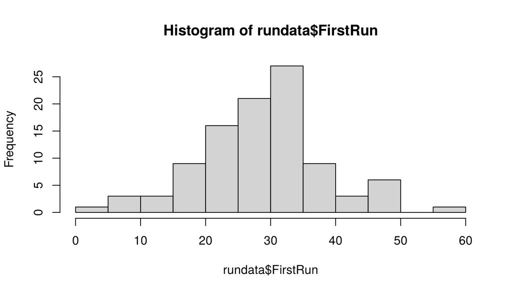

```r
hist(rundata$FirstRun)
```

## Histogram options (`?hist`)

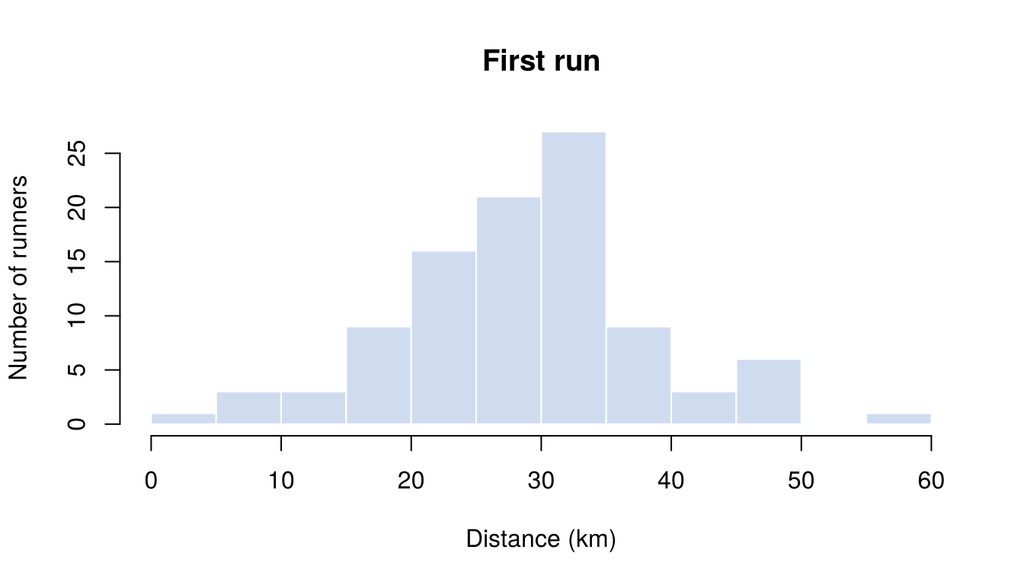

```r
hist(rundata$FirstRun, breaks = 15, col = "#cfdcf0", border = "white",
     ylab = "Number of runners", xlab = "Distance (km)", main = "First run")
```

The sheet’s example `hist(exams$First.Test, ylab="y-axis title", xlab=”x-axis title", main=“main title”)` refers to an `exams` data frame that doesn’t exist in this tutorial, and uses curly quotes. Use `rundata$FirstRun` as above.

## Density and the probability of running 20–25 km

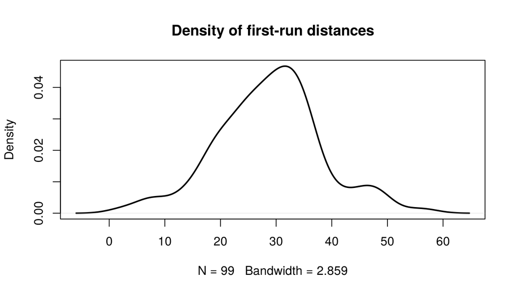

```r
dens <- density(rundata$FirstRun)        # a smooth estimate of the distribution
plot(dens, main = "Density of first-run distances", lwd = 2)
```

```r
convertToFunc <- with(dens, splinefun(x, y))   # turn the density points into a function
integrate(convertToFunc, lower = 20, upper = 25)   # area under the curve = probability
```

```
## 0.1605854 with absolute error < 2.3e-06
```

```r
mean(rundata$FirstRun >= 20 & rundata$FirstRun <= 25)   # check: the observed proportion
```

```
## [1] 0.1616162
```

About 16% of runners ran between 20 and 25 km in their first run; the density estimate and the raw proportion agree.

## Normality testing

```r
shapiro.test(rundata$FirstRun)
```

```
##
##  Shapiro-Wilk normality test
##
## data:  rundata$FirstRun
## W = 0.98583, p-value = 0.371
```

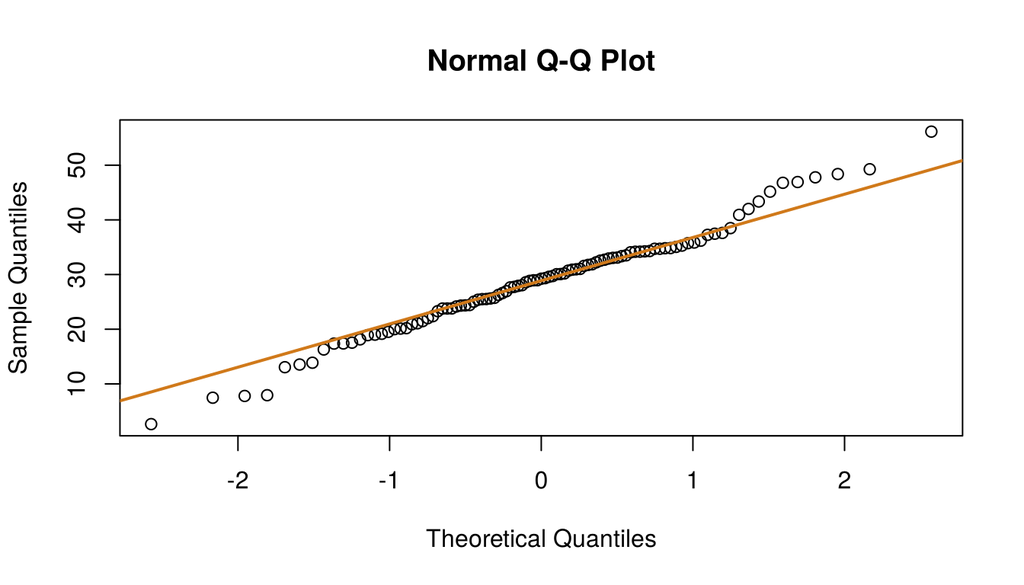

```r
qqnorm(rundata$FirstRun); qqline(rundata$FirstRun, col = "#d0791a", lwd = 2)
```

H0: the data come from a normal distribution. H1: they don’t. Here p > 0.05, so there’s no evidence against normality, and the Q–Q plot is close to a straight line.

## Comparing the runs

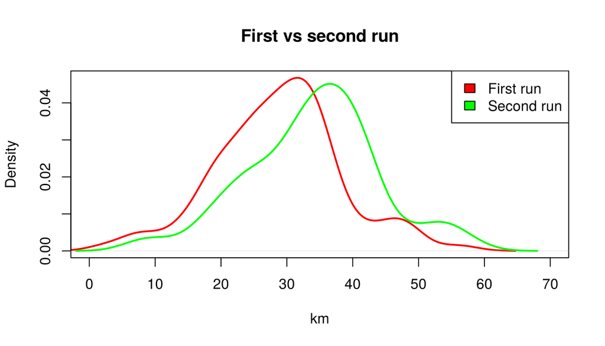

```r
plot(density(rundata$FirstRun), col = "red", lwd = 2, xlim = c(0, 70),
     main = "First vs second run", xlab = "km")
lines(density(rundata$SecondRun), col = "green", lwd = 2)
legend("topright", legend = c("First run", "Second run"), fill = c("red", "green"))
```

The second-run curve is shifted right: people ran further the second time, with a similar spread.

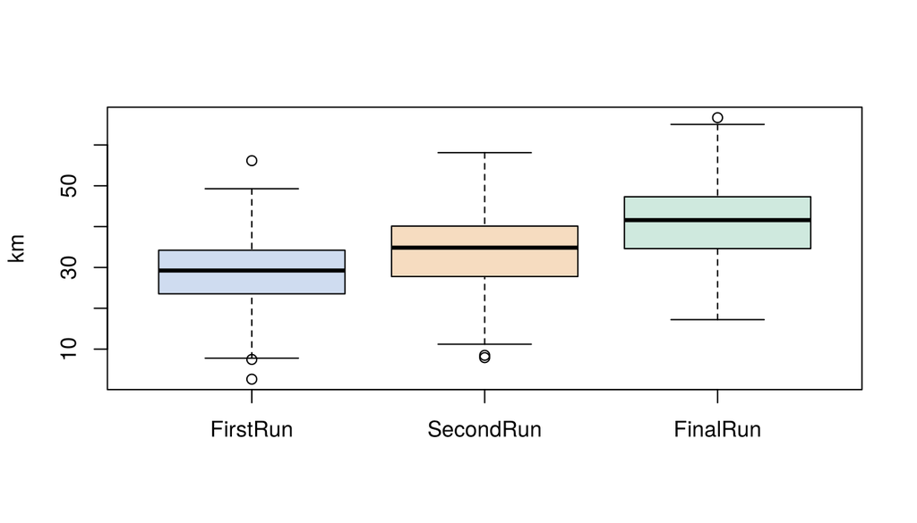

```r
boxplot(rundata, col = c("#cfdcf0", "#f6dcc0", "#cfe9de"), ylab = "km")   # one box per column
```

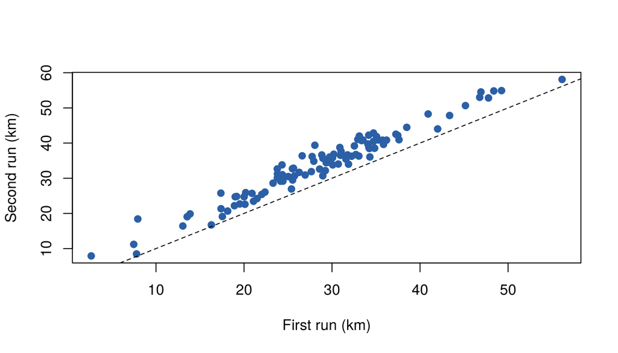

```r
plot(rundata$FirstRun, rundata$SecondRun, pch = 19, col = "#2b5fa6",
     xlab = "First run (km)", ylab = "Second run (km)")
abline(0, 1, lty = 2)        # points above this line ran further the second time
```

# Exercise 4: other probability distributions

## Binomial: guessing a 20-question multiple-choice test

```r
dbinom(10, size = 20, prob = 0.25)    # P(exactly 10 correct) = 0.0099
```

```
## [1] 0.009922275
```

```r
pbinom(10, size = 20, prob = 0.25)    # P(10 or fewer) = 0.996
```

```
## [1] 0.9960579
```

```r
1 - pbinom(9, size = 20, prob = 0.25) # P(10 or more): pass by guessing? about 1.4%
```

```
## [1] 0.01386442
```

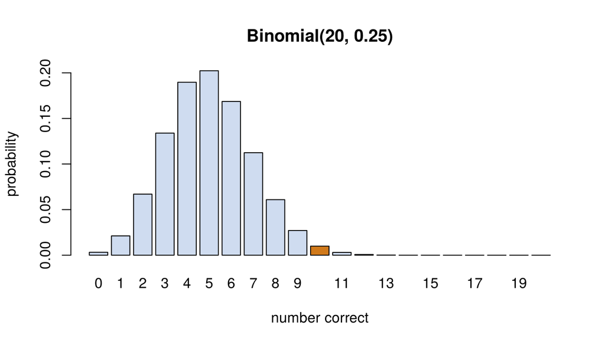

```r
barplot(dbinom(0:20, 20, 0.25), names.arg = 0:20, col = ifelse(0:20 == 10, "#d0791a", "#cfdcf0"),
        xlab = "number correct", ylab = "probability", main = "Binomial(20, 0.25)")
```

## Poisson: people in a coffee-shop queue (mean 7)

```r
ppois(6, lambda = 7)                  # P(X <= 6) = 0.450: six or fewer
```

```
## [1] 0.4497111
```

```r
1 - ppois(6, lambda = 7)              # P(X >= 7) = 0.550: seven or more
```

```
## [1] 0.5502889
```

```r
ppois(6, lambda = 7, lower = FALSE)   # the same thing: P(X > 6)
```

```
## [1] 0.5502889
```

```r
1 - ppois(5, lambda = 7)              # P(X >= 6) = 0.699: SIX or more
```

```
## [1] 0.6992917
```

**Off-by-one in the sheet.** It says “the probability of having 6 or more people is `1 - ppois(6, lambda = 7)`”. That’s actually P(X ≥ **7**), because `ppois(6)` already includes 6. For “6 or more” use `1 - ppois(5, 7)` or `ppois(5, 7, lower.tail = FALSE)`. For discrete distributions always ask: is the boundary value included?

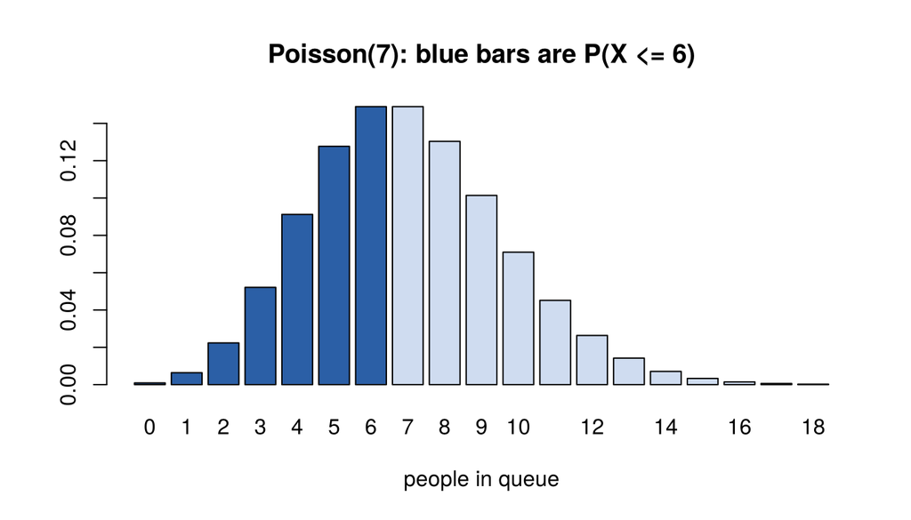

```r
barplot(dpois(0:18, 7), names.arg = 0:18, col = ifelse(0:18 <= 6, "#2b5fa6", "#cfdcf0"),
        xlab = "people in queue", main = "Poisson(7): blue bars are P(X <= 6)")
```

## Exponential: delivery times with mean 10 minutes

```r
pexp(5, rate = 1/10)           # P(delivery < 5 min) = 0.393
```

```
## [1] 0.3934693
```

```r
1 - pexp(20, rate = 1/10)      # P(longer than 20 min) = 0.135
```

```
## [1] 0.1353353
```

```r
qexp(0.9, rate = 1/10)         # 90% of deliveries arrive within 23 minutes
```

```
## [1] 23.02585
```

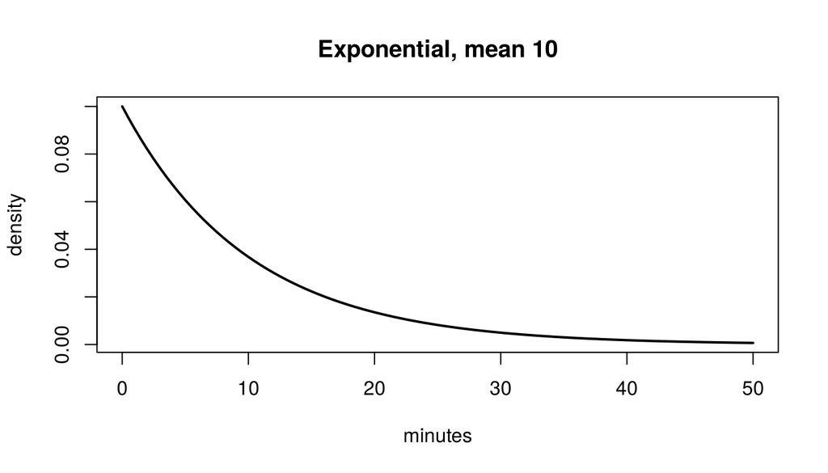

```r
curve(dexp(x, 1/10), 0, 50, lwd = 2, xlab = "minutes", ylab = "density", main = "Exponential, mean 10")
```

## More distributions (r-tutor)

```r
punif(3, min = 0, max = 10)            # uniform: P(X < 3) = 0.3
```

```
## [1] 0.3
```

```r
pnorm(70, mean = 55, sd = 10)          # normal: P(mark < 70)
```

```
## [1] 0.9331928
```

```r
pt(2.1, df = 15, lower.tail = FALSE)   # t: upper tail, used in t-tests
```

```
## [1] 0.02652763
```

```r
pchisq(5.99, df = 2, lower.tail = FALSE)   # chi-squared: about 0.05
```

```
## [1] 0.05003663
```

```r
qchisq(0.95, df = 2)                   # the 5% critical value: 5.99
```

```
## [1] 5.991465
```

```r
pf(3.5, df1 = 2, df2 = 27, lower.tail = FALSE)   # F: used in ANOVA
```

```
## [1] 0.04450875
```

Every distribution in R has four functions: `d` (density/probability), `p` (cumulative probability), `q` (quantile, the inverse of `p`) and `r` (random numbers). For example `dnorm`, `pnorm`, `qnorm`, `rnorm`.

# Summary of fixes to the sheets

| Sheet | Line | Problem | Fix |
| --- | --- | --- | --- |
| Ex 1 | `x[is.na(x)] <- mean(x)` | `mean(x)` is NA | `mean(x, na.rm = TRUE)` |
| Ex 1 | `factor(c(“U”, ...))` | curly quotes | straight quotes |
| Ex 1 | `rowSums <- apply(...)` | masks built-in function names | use different names |
| Ex 2 | `am==1` labelled “auto” | labels swapped | 1 = manual, 0 = automatic |
| Ex 2 | `vs` called engine size | wrong variable meaning | `vs` = engine shape; size is `disp` |
| Ex 3 | `hist(exams$First.Test, ...)` | no `exams` object; curly quotes | `hist(rundata$FirstRun, ...)` |
| Ex 4 | “6 or more” = `1 - ppois(6, 7)` | that is 7 or more | `1 - ppois(5, 7)` |